# 03 AF 10K Ever Gave Classification

## Trimmed 3

Drop `GIVING_MAX_CASH_YR`.

```r
# Store model errors
errs_glm_trimmed3 <- data.frame(
    reps = rep(1:reps, each = folds)
  , folds = rep(1:folds, times = reps)
  , error = 0
  , precision = 0
  , sensitivity = 0
  , F1_score = 0
)
confus_glm_trimmed3 <- rep(list(NULL), times = reps * folds)
# Seed for reproducibility
set.seed(702305)
for (rep in 1:reps) {
  # Status report
  paste('+ Iteration', rep, 'beginning at', Sys.time()) %>% print()
  # Create cross-validation indices
  xv <- KFoldXVal(traindat, k = folds)
  for (fold in 1:length(xv)) {
    # Fit temp model
    tmpmodel <- glm(GAVE_10K ~
        + ns(RECORD_YR, df = 10)
        + PROGRAM_GROUP + PREF_ADDR_TYPE_CODE + HOUSEHOLD_CONTINENT
        + GIVING_PLEDGE_ANY
        + GIVING_PLEDGE_FIRST_YR + GIFTS_ALLOCS_SUPPORTED
        + GIFTS_CASH + GIFTS_CREDIT_CARD + GIFTS_STOCK + GIFT_CLUB_KLC_YRS
        + GIFT_CLUB_NU_LDR_YRS + GIFT_CLUB_LOYAL_YRS
        + ns(VELOCITY3_LIN, df = 3)
      # Train while withholding some data
      , data = traindat[-xv[[fold]], ]
      , family = binomial) %>% suppressMessages()
    # Prediction threshold
    theta1 <- sum(traindat$GAVE_10K[-xv[[fold]]] == 1) / nrow(traindat[-xv[[fold]], ])
    # Confusion matrix based on the withheld data
    tmpconfus <- conf_matrix(tmpmodel, newdata = traindat[xv[[fold]], ], threshold = theta1)
    # Write results to errors data frame
    errs_glm_trimmed3 <- errs_glm_trimmed3 %>% mutate(
        error = case_when(
            reps == rep & folds == fold ~ tmpconfus$error
          , TRUE ~ error)
      , precision = case_when(
            reps == rep & folds == fold ~ tmpconfus$precision
          , TRUE ~ precision)
      , sensitivity = case_when(
            reps == rep & folds == fold ~ tmpconfus$sensitivity
          , TRUE ~ sensitivity)
      , F1_score = case_when(
            reps == rep & folds == fold ~ tmpconfus$F1_score
          , TRUE ~ F1_score)
    )
    # Write confusion matrix to list
    confus_glm_trimmed3[[(rep - 1) * folds + fold]] <- tmpconfus$conf_matrix
  }
  # Status report
  paste('-- Iteration', rep, 'ending at', Sys.time()) %>% print()
}
```

```
[1] "+ Iteration 1 beginning at 2018-01-23 09:38:17"
[1] "-- Iteration 1 ending at 2018-01-23 09:39:09"
[1] "+ Iteration 2 beginning at 2018-01-23 09:39:09"
[1] "-- Iteration 2 ending at 2018-01-23 09:40:13"
[1] "+ Iteration 3 beginning at 2018-01-23 09:40:13"
[1] "-- Iteration 3 ending at 2018-01-23 09:41:16"
[1] "+ Iteration 4 beginning at 2018-01-23 09:41:16"
[1] "-- Iteration 4 ending at 2018-01-23 09:42:16"
[1] "+ Iteration 5 beginning at 2018-01-23 09:42:16"
[1] "-- Iteration 5 ending at 2018-01-23 09:43:04"
```

```r
data.frame(
    baseline = errs_glm_baseline %>% select(error, precision, sensitivity)
    %>% colMeans() %>% round(4)
  , trimmed = errs_glm_trimmed %>% select(error, precision, sensitivity)
    %>% colMeans() %>% round(4)
  , trimmed2 = errs_glm_trimmed2 %>% select(error, precision, sensitivity)
    %>% colMeans() %>% round(4)
  , trimmed3 = errs_glm_trimmed3 %>% select(error, precision, sensitivity)
    %>% colMeans() %>% round(4)
)
```

|  | baseline | trimmed | trimmed2 | trimmed3 |
| --- | --- | --- | --- | --- |
| error | 0.0705 | 0.0703 | 0.0806 | 0.0715 |
| precision | 0.1370 | 0.1378 | 0.1216 | 0.1318 |
| sensitivity | 0.9364 | 0.9396 | 0.9341 | 0.9039 |

```r
mtrim3 <- glm(GAVE_10K ~
        + ns(RECORD_YR, df = 10)
        + PROGRAM_GROUP + PREF_ADDR_TYPE_CODE + HOUSEHOLD_CONTINENT
        + GIVING_PLEDGE_ANY
        + GIVING_PLEDGE_FIRST_YR + GIFTS_ALLOCS_SUPPORTED
        + GIFTS_CASH + GIFTS_CREDIT_CARD + GIFTS_STOCK + GIFT_CLUB_KLC_YRS
        + GIFT_CLUB_NU_LDR_YRS + GIFT_CLUB_LOYAL_YRS
        + ns(VELOCITY3_LIN, df = 3)
      , data = traindat
      , family = binomial)
```

## Trimmed 4

Drop `GIFTS_CASH`

```r
# Store model errors
errs_glm_trimmed4 <- data.frame(
    reps = rep(1:reps, each = folds)
  , folds = rep(1:folds, times = reps)
  , error = 0
  , precision = 0
  , sensitivity = 0
  , F1_score = 0
)
confus_glm_trimmed4 <- rep(list(NULL), times = reps * folds)
# Seed for reproducibility
set.seed(995439)
for (rep in 1:reps) {
  # Status report
  paste('+ Iteration', rep, 'beginning at', Sys.time()) %>% print()
  # Create cross-validation indices
  xv <- KFoldXVal(traindat, k = folds)
  for (fold in 1:length(xv)) {
    # Fit temp model
    tmpmodel <- glm(GAVE_10K ~
        + ns(RECORD_YR, df = 10)
        + PROGRAM_GROUP + PREF_ADDR_TYPE_CODE + HOUSEHOLD_CONTINENT
        + GIVING_PLEDGE_ANY
        + GIVING_PLEDGE_FIRST_YR + GIFTS_ALLOCS_SUPPORTED
        + GIFTS_CREDIT_CARD + GIFTS_STOCK + GIFT_CLUB_KLC_YRS
        + GIFT_CLUB_NU_LDR_YRS + GIFT_CLUB_LOYAL_YRS
        + ns(VELOCITY3_LIN, df = 3)
      # Train while withholding some data
      , data = traindat[-xv[[fold]], ]
      , family = binomial) %>% suppressMessages()
    # Prediction threshold
    theta1 <- sum(traindat$GAVE_10K[-xv[[fold]]] == 1) / nrow(traindat[-xv[[fold]], ])
    # Confusion matrix based on the withheld data
    tmpconfus <- conf_matrix(tmpmodel, newdata = traindat[xv[[fold]], ], threshold = theta1)
    # Write results to errors data frame
    errs_glm_trimmed4 <- errs_glm_trimmed4 %>% mutate(
        error = case_when(
            reps == rep & folds == fold ~ tmpconfus$error
          , TRUE ~ error)
      , precision = case_when(
            reps == rep & folds == fold ~ tmpconfus$precision
          , TRUE ~ precision)
      , sensitivity = case_when(
            reps == rep & folds == fold ~ tmpconfus$sensitivity
          , TRUE ~ sensitivity)
      , F1_score = case_when(
            reps == rep & folds == fold ~ tmpconfus$F1_score
          , TRUE ~ F1_score)
    )
    # Write confusion matrix to list
    confus_glm_trimmed4[[(rep - 1) * folds + fold]] <- tmpconfus$conf_matrix
  }
  # Status report
  paste('-- Iteration', rep, 'ending at', Sys.time()) %>% print()
}
```

```
[1] "+ Iteration 1 beginning at 2018-01-23 09:45:11"
[1] "-- Iteration 1 ending at 2018-01-23 09:45:54"
[1] "+ Iteration 2 beginning at 2018-01-23 09:45:54"
[1] "-- Iteration 2 ending at 2018-01-23 09:46:36"
[1] "+ Iteration 3 beginning at 2018-01-23 09:46:36"
[1] "-- Iteration 3 ending at 2018-01-23 09:47:19"
[1] "+ Iteration 4 beginning at 2018-01-23 09:47:19"
[1] "-- Iteration 4 ending at 2018-01-23 09:48:03"
[1] "+ Iteration 5 beginning at 2018-01-23 09:48:03"
[1] "-- Iteration 5 ending at 2018-01-23 09:48:45"
```

```r
data.frame(
    baseline = errs_glm_baseline %>% select(error, precision, sensitivity)
    %>% colMeans() %>% round(4)
  , trimmed = errs_glm_trimmed %>% select(error, precision, sensitivity)
    %>% colMeans() %>% round(4)
  , trimmed2 = errs_glm_trimmed2 %>% select(error, precision, sensitivity)
    %>% colMeans() %>% round(4)
  , trimmed3 = errs_glm_trimmed3 %>% select(error, precision, sensitivity)
    %>% colMeans() %>% round(4)
  , trimmed4 = errs_glm_trimmed4 %>% select(error, precision, sensitivity)
    %>% colMeans() %>% round(4)
)
```

|  | baseline | trimmed | trimmed2 | trimmed3 | trimmed4 |
| --- | --- | --- | --- | --- | --- |
| error | 0.0705 | 0.0703 | 0.0806 | 0.0715 | 0.0716 |
| precision | 0.1370 | 0.1378 | 0.1216 | 0.1318 | 0.1317 |
| sensitivity | 0.9364 | 0.9396 | 0.9341 | 0.9039 | 0.9052 |

# Spline models

## Spline degrees of freedom

I’ll use natural splines on the numeric predictors but each variable should have some maximum degrees of freedom.

```r
mdat %>%
  glm(GAVE_10K ~
        + ns(RECORD_YR, df = 20)
        + PROGRAM_GROUP + PREF_ADDR_TYPE_CODE + HOUSEHOLD_CONTINENT
        + GIVING_PLEDGE_ANY
        + GIVING_PLEDGE_FIRST_YR + GIFTS_ALLOCS_SUPPORTED
        + GIFTS_CREDIT_CARD + GIFTS_STOCK + GIFT_CLUB_KLC_YRS
        + GIFT_CLUB_NU_LDR_YRS + GIFT_CLUB_LOYAL_YRS
        + ns(VELOCITY3_LIN, df = 5)
      , data = .
      , family = binomial) %>%
  summary()
```

```
Call:
glm(formula = GAVE_10K ~ +ns(RECORD_YR, df = 20) + PROGRAM_GROUP +
    PREF_ADDR_TYPE_CODE + HOUSEHOLD_CONTINENT + GIVING_PLEDGE_ANY +
    GIVING_PLEDGE_FIRST_YR + GIFTS_ALLOCS_SUPPORTED + GIFTS_CREDIT_CARD +
    GIFTS_STOCK + GIFT_CLUB_KLC_YRS + GIFT_CLUB_NU_LDR_YRS +
    GIFT_CLUB_LOYAL_YRS + ns(VELOCITY3_LIN, df = 5), family = binomial,
    data = .)

Deviance Residuals:
    Min       1Q   Median       3Q      Max
-4.1204  -0.0627  -0.0440  -0.0341   4.1904

Coefficients:
                                  Estimate Std. Error z value Pr(>|z|)
(Intercept)                       15.56666    2.44577   6.365 1.96e-10 ***
ns(RECORD_YR, df = 20)1            3.19289    1.57541   2.027  0.04269 *
ns(RECORD_YR, df = 20)2            4.10692    1.89453   2.168  0.03018 *
ns(RECORD_YR, df = 20)3            3.62605    1.73498   2.090  0.03662 *
ns(RECORD_YR, df = 20)4            4.17775    1.84844   2.260  0.02381 *
ns(RECORD_YR, df = 20)5            3.15858    1.78024   1.774  0.07602 .
ns(RECORD_YR, df = 20)6            3.66960    1.77879   2.063  0.03912 *
ns(RECORD_YR, df = 20)7            3.14030    1.77048   1.774  0.07611 .
ns(RECORD_YR, df = 20)8            3.50160    1.77374   1.974  0.04837 *
ns(RECORD_YR, df = 20)9            2.86942    1.77931   1.613  0.10682
ns(RECORD_YR, df = 20)10           3.60055    1.78294   2.019  0.04344 *
ns(RECORD_YR, df = 20)11           3.68613    1.79380   2.055  0.03989 *
ns(RECORD_YR, df = 20)12           3.37535    1.78535   1.891  0.05868 .
ns(RECORD_YR, df = 20)13           3.47067    1.81320   1.914  0.05561 .
ns(RECORD_YR, df = 20)14           3.81876    1.82732   2.090  0.03663 *
ns(RECORD_YR, df = 20)15           3.75904    1.80619   2.081  0.03742 *
ns(RECORD_YR, df = 20)16           3.49771    1.83716   1.904  0.05693 .
ns(RECORD_YR, df = 20)17           3.29926    1.87826   1.757  0.07899 .
ns(RECORD_YR, df = 20)18          -0.18095    1.32320  -0.137  0.89123
ns(RECORD_YR, df = 20)19           8.59329    3.74991   2.292  0.02193 *
ns(RECORD_YR, df = 20)20          -0.04659    1.03155  -0.045  0.96398
PROGRAM_GROUPNONE                  1.86754    0.16406  11.383  < 2e-16 ***
PROGRAM_GROUPEMP                  -0.41693    0.23134  -1.802  0.07151 .
PROGRAM_GROUPEXECED               -1.05003    0.44826  -2.342  0.01916 *
PROGRAM_GROUPNONGRD               -0.41891    0.62862  -0.666  0.50516
PROGRAM_GROUPPHD                   0.62422    0.48898   1.277  0.20175
```

[output cut: 18 more lines]

```
ns(VELOCITY3_LIN, df = 5)1       -21.51308    1.41935 -15.157  < 2e-16 ***
ns(VELOCITY3_LIN, df = 5)2       -26.01648    1.71744 -15.148  < 2e-16 ***
ns(VELOCITY3_LIN, df = 5)3       -20.35174    1.13675 -17.903  < 2e-16 ***
ns(VELOCITY3_LIN, df = 5)4       -57.96467    4.23807 -13.677  < 2e-16 ***
ns(VELOCITY3_LIN, df = 5)5        12.77897    1.45164   8.803  < 2e-16 ***
---
Signif. codes:  0 ‘***’ 0.001 ‘**’ 0.01 ‘*’ 0.05 ‘.’ 0.1 ‘ ’ 1

(Dispersion parameter for binomial family taken to be 1)

    Null deviance: 11017.9  on 86233  degrees of freedom
Residual deviance:  4448.9  on 86185  degrees of freedom
AIC: 4546.9

Number of Fisher Scoring iterations: 16
```

Proposed grid search:

`RECORD_YR` $\in \left\{5, 10, 15, 20 \right\}$ `VELOCITY3_LIN` $\in \left\{2, 3, 4, 5 \right\}$

This gives 4 * 4 = 16 possibilities.

```r
# Splines grid search parameters
grid_params = list(
    RECORD_YR = c(5, 10, 15, 20)
  , VELOCITY3_LIN = c(2, 3, 4, 5)
)
```

## Spine df grid search

```r
# Store model errors
errs_glm_splines <- data.frame(NULL)
# Seed for reproducibility
set.seed(5544999)
for (rep in 1:reps) {
  # Status report
  paste('+ Iteration', rep, 'beginning at', Sys.time()) %>% print()
  # Create cross-validation indices
  xv <- KFoldXVal(traindat, k = folds)
  for (fold in 1:length(xv)) {
    # Status report
    paste(' + Fold', fold, 'beginning at', Sys.time()) %>% print()
    # Go through grid search parameters (parallel)
    prlout <- foreach (yr = grid_params$RECORD_YR, .combine = rbind) %:%
      foreach(vel = grid_params$VELOCITY3_LIN
                , .combine = rbind
                , .packages = c('dplyr', 'splines')
              ) %dopar% {
        # Fit temp model
        tmpmodel <- glm(GAVE_10K ~
                          + ns(RECORD_YR, df = yr)
                          + PROGRAM_GROUP + PREF_ADDR_TYPE_CODE + HOUSEHOLD_CONTINENT
                          + GIVING_PLEDGE_ANY
                          + GIVING_PLEDGE_FIRST_YR + GIFTS_ALLOCS_SUPPORTED
                          + GIFTS_CREDIT_CARD + GIFTS_STOCK + GIFT_CLUB_KLC_YRS
                          + GIFT_CLUB_NU_LDR_YRS + GIFT_CLUB_LOYAL_YRS
                          + ns(VELOCITY3_LIN, df = vel)
                          # Train while withholding some data
                          , data = traindat[-xv[[fold]], ]
                          , family = binomial) %>% suppressMessages()
        # Prediction threshold
        theta1 <- sum(traindat$GAVE_10K[-xv[[fold]]] == 1) / nrow(traindat[-xv[[fold]], ])
        # Confusion matrix based on the withheld data
        tmpconfus <- conf_matrix(tmpmodel, newdata = traindat[xv[[fold]], ], threshold = theta1)
        # Return results
        return(
          data.frame(
              reps = rep
            , folds = fold
            , yr_df = yr
            , vel_df = vel
            , error = tmpconfus$error
            , precision = tmpconfus$precision
            , sensitivity = tmpconfus$sensitivity
            , F1_score = tmpconfus$F1_score
          )
        )
      }
    # Write results to errors data frame
    errs_glm_splines <- errs_glm_splines %>% rbind(prlout)
    # Status report
    paste(' -- Fold', fold, 'ending at', Sys.time()) %>% print()
  }
  # Status report
  paste('-- Iteration', rep, 'ending at', Sys.time()) %>% print()
}
```

```
[1] "+ Iteration 1 beginning at 2018-01-23 13:23:23"
[1] " + Fold 1 beginning at 2018-01-23 13:23:23"
[1] " -- Fold 1 ending at 2018-01-23 13:24:10"
[1] " + Fold 2 beginning at 2018-01-23 13:24:10"
[1] " -- Fold 2 ending at 2018-01-23 13:24:57"
[1] " + Fold 3 beginning at 2018-01-23 13:24:57"
[1] " -- Fold 3 ending at 2018-01-23 13:25:42"
[1] " + Fold 4 beginning at 2018-01-23 13:25:42"
[1] " -- Fold 4 ending at 2018-01-23 13:26:27"
[1] " + Fold 5 beginning at 2018-01-23 13:26:27"
[1] " -- Fold 5 ending at 2018-01-23 13:27:12"
[1] " + Fold 6 beginning at 2018-01-23 13:27:12"
[1] " -- Fold 6 ending at 2018-01-23 13:28:00"
[1] " + Fold 7 beginning at 2018-01-23 13:28:00"
[1] " -- Fold 7 ending at 2018-01-23 13:28:46"
```

[output cut: 95 more lines]

Plot results.

```r
gridplotter <- function(data, var) {
  data %>% mutate(z = data[, var]) %>%
    group_by(vel_df, yr_df) %>%
    summarise(z = mean(z)) %>%
    ggplot(aes(x = vel_df, y = yr_df)) +
    geom_tile(aes(fill = z)) +
    geom_text(aes(label = z %>% round(4))) +
    labs(title = var)
}
```

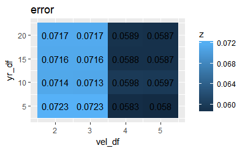

```r
gridplotter(errs_glm_splines, 'error')
```

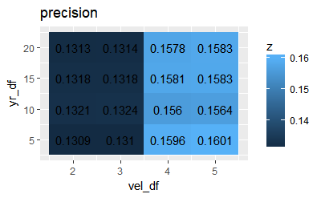

```r
gridplotter(errs_glm_splines, 'precision')
```

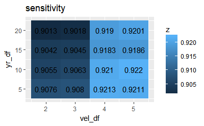

```r
gridplotter(errs_glm_splines, 'sensitivity')
```

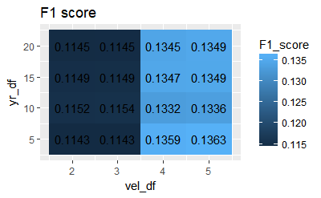

```r
errs_glm_splines %>% group_by(vel_df, yr_df) %>% summarise(F1_score = mean(F1_score)) %>%
  ggplot(aes(x = vel_df, y = yr_df)) +
  geom_tile(aes(fill = F1_score)) +
  geom_text(aes(label = F1_score %>% round(4))) +
  labs(title = 'F1 score')
```

Looks like vel_df of 4 and 5 are indistinguishable, so let’s set to 4.

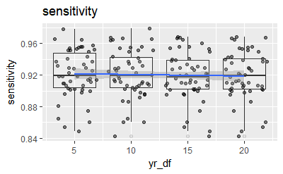

```r
set.seed(123)
errs_glm_splines %>% filter(vel_df == 4) %>%
  ggplot(aes(x = yr_df, y = sensitivity)) +
  geom_jitter(alpha = .5) +
  geom_boxplot(aes(group = yr_df), alpha = .1) +
  geom_smooth(method = 'gam') +
  labs(title = 'sensitivity')
```

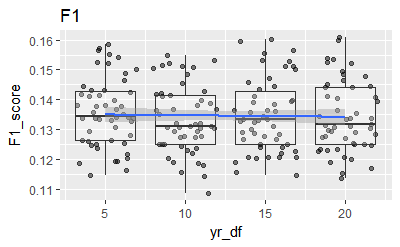

```r
set.seed(123)
errs_glm_splines %>% filter(vel_df == 4) %>%
  ggplot(aes(x = yr_df, y = F1_score)) +
  geom_jitter(alpha = .5) +
  geom_boxplot(aes(group = yr_df), alpha = .25) +
  geom_smooth(method = 'gam') +
  labs(title = 'F1')
```

Looks like fewer df might actually have a slight advantage?

```r
errs_glm_splines %>% filter(vel_df == 4) %>%
  aov(F1_score ~ yr_df, data = .) %>% summary()
```

```
             Df   Sum Sq   Mean Sq F value Pr(>F)
yr_df         1 0.000017 1.716e-05   0.126  0.723
Residuals   198 0.027066 1.367e-04
```

No apparent difference; let’s go with 5 df.

```r
data.frame(
    baseline = errs_glm_baseline %>% select(error, precision, sensitivity)
    %>% colMeans() %>% round(4)
  , trimmed = errs_glm_trimmed %>% select(error, precision, sensitivity)
    %>% colMeans() %>% round(4)
  , trimmed2 = errs_glm_trimmed2 %>% select(error, precision, sensitivity)
    %>% colMeans() %>% round(4)
  , trimmed3 = errs_glm_trimmed3 %>% select(error, precision, sensitivity)
    %>% colMeans() %>% round(4)
  , trimmed4 = errs_glm_trimmed4 %>% select(error, precision, sensitivity)
    %>% colMeans() %>% round(4)
  , splines = errs_glm_splines %>% filter(yr_df == 5 & vel_df == 4) %>%
    select(error, precision, sensitivity) %>% colMeans() %>% round(4)
)
```

|  | baseline | trimmed | trimmed2 | trimmed3 | trimmed4 | splines |
| --- | --- | --- | --- | --- | --- | --- |
| error | 0.0705 | 0.0703 | 0.0806 | 0.0715 | 0.0716 | 0.0583 |
| precision | 0.1370 | 0.1378 | 0.1216 | 0.1318 | 0.1317 | 0.1596 |
| sensitivity | 0.9364 | 0.9396 | 0.9341 | 0.9039 | 0.9052 | 0.9213 |

Potential concern: is `VELOCITY3_LIN` with moderate to high df too correlated?

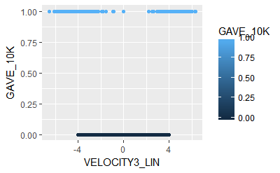

```r
traindat %>% select(GAVE_10K, VELOCITY3_LIN) %>%
  ggplot(aes(x = VELOCITY3_LIN, y = GAVE_10K, color = GAVE_10K)) +
  geom_point()
```

On the other hand, we do want to pay special attention to upgrades/downgrades.

# Coefficient shrinkage

## Non-penalized GLM

```r
# Store model errors
errs_glm_nonpen <- data.frame(NULL)
# Seed for reproducibility
set.seed(9860543)
for (rep in 1:reps) {
  # Status report
  paste('+ Iteration', rep, 'beginning at', Sys.time()) %>% print()
  # Create cross-validation indices
  xv <- KFoldXVal(traindat, k = folds)
  prlout <- foreach (fold = 1:length(xv)
                     , .combine = rbind
                     , .packages = c('dplyr', 'splines')) %dopar% {
    # Fit temp model
    tmpmodel <- glm(GAVE_10K ~
                        ns(RECORD_YR, df = 5)
                      + PROGRAM_GROUP + PREF_ADDR_TYPE_CODE + HOUSEHOLD_CONTINENT
                      + GIVING_PLEDGE_ANY
                      + GIVING_PLEDGE_FIRST_YR + GIFTS_ALLOCS_SUPPORTED
                      + GIFTS_CREDIT_CARD + GIFTS_STOCK + GIFT_CLUB_KLC_YRS
                      + GIFT_CLUB_NU_LDR_YRS + GIFT_CLUB_LOYAL_YRS
                      + ns(VELOCITY3_LIN, df = 4)
                      # Train while withholding some data
                      , data = traindat[-xv[[fold]], ]
                      , family = binomial) %>% suppressMessages()
    # Prediction threshold
    theta1 <- sum(traindat$GAVE_10K[-xv[[fold]]] == 1) / nrow(traindat[-xv[[fold]], ])
    # Confusion matrix based on the withheld data
    tmpconfus <- conf_matrix(tmpmodel, newdata = traindat[xv[[fold]], ], threshold = theta1)
    # Return results
    return(
      data.frame(
          reps = rep
        , folds = fold
        , yr_df = yr
        , vel_df = vel
        , error = tmpconfus$error
        , precision = tmpconfus$precision
        , sensitivity = tmpconfus$sensitivity
        , F1_score = tmpconfus$F1_score
      )
    )
  }
  # Write results to errors data frame
  errs_glm_nonpen <- errs_glm_nonpen %>% rbind(prlout)
  # Status report
  paste('-- Iteration', rep, 'ending at', Sys.time()) %>% print()
}
```

```
[1] "+ Iteration 1 beginning at 2018-01-24 09:29:44"
[1] "-- Iteration 1 ending at 2018-01-24 09:30:04"
[1] "+ Iteration 2 beginning at 2018-01-24 09:30:04"
[1] "-- Iteration 2 ending at 2018-01-24 09:30:22"
[1] "+ Iteration 3 beginning at 2018-01-24 09:30:22"
[1] "-- Iteration 3 ending at 2018-01-24 09:30:43"
[1] "+ Iteration 4 beginning at 2018-01-24 09:30:43"
[1] "-- Iteration 4 ending at 2018-01-24 09:31:01"
[1] "+ Iteration 5 beginning at 2018-01-24 09:31:01"
[1] "-- Iteration 5 ending at 2018-01-24 09:31:20"
```

## Penalized GLM

Need a new function to construct a glmnet confusion matrix.

```r
conf_matrix_glmnet <- function(model, newdata = NULL, threshold = .5) {
  results <- data.frame(
    predict(model, newdata = newdata, type = 'response'
            , s = 'lambda.1se') >= threshold
  ) %>% select(pred = X1)
  if (is.null(newdata)) {
    results$truth = model$y
  } else {
    results$truth = newdata$GAVE_10K
  }
  results_tbl <- table(truth = results$truth, prediction = results$pred)
  error <- (results_tbl[1, 2] + results_tbl[2, 1]) / sum(results_tbl)
  precision <- results_tbl[2, 2] / sum(results_tbl[, 2])
  sensitivity <- results_tbl[2, 2] / sum(results_tbl[2, ])
  return(
    list(
      # Confusion matrix counts
        conf_matrix = results_tbl
      # Confusion matrix percents
      , conf_matrix_pct = results_tbl / nrow(results)
      # Statistics
      , error = error
      , precision = precision
      , sensitivity = sensitivity
      , F1_score = (precision * sensitivity) / (precision + sensitivity)
    )
  )
}
```

```r
# Store model errors
errs_glm_pen <- data.frame(NULL)
# Seed for reproducibility
set.seed(8774272)
for (rep in 1:reps) {
  # Status report
  paste('+ Iteration', rep, 'beginning at', Sys.time()) %>% print()
  # Create cross-validation indices
  xv <- KFoldXVal(traindat, k = folds)
  prlout <- foreach (fold = 1:length(xv)
           , .combine = rbind
           , .packages = c('glmnet', 'glmnetUtils', 'dplyr', 'splines')) %dopar% {
    # alpha = 0 is the ridge regression penalty
    tmpmodel <- cv.glmnet(as.factor(GAVE_10K) ~
                           ns(RECORD_YR, df = 5)
                         + PROGRAM_GROUP + PREF_ADDR_TYPE_CODE + HOUSEHOLD_CONTINENT
                         + GIVING_PLEDGE_ANY
                         + GIVING_PLEDGE_FIRST_YR + GIFTS_ALLOCS_SUPPORTED
                         + GIFTS_CREDIT_CARD + GIFTS_STOCK + GIFT_CLUB_KLC_YRS
                         + GIFT_CLUB_NU_LDR_YRS + GIFT_CLUB_LOYAL_YRS
                         + ns(VELOCITY3_LIN, df = 4)
                         # Train while withholding some data
                         , data = traindat[-xv[[fold]], ]
                         , family = 'binomial'
                         , alpha = 0
                         , lambda = 2^(-8:5))
    # Prediction threshold
    theta1 <- sum(traindat$GAVE_10K[-xv[[fold]]] == 1) / nrow(traindat[-xv[[fold]], ])
    # Confusion matrix based on the withheld data
    tmpconfus <- conf_matrix_glmnet(tmpmodel, newdata = traindat[xv[[fold]], ], threshold = theta1)
    # Return results
    return(
     data.frame(
       reps = rep
       , folds = fold
       , yr_df = yr
       , vel_df = vel
       , error = tmpconfus$error
       , precision = tmpconfus$precision
       , sensitivity = tmpconfus$sensitivity
       , F1_score = tmpconfus$F1_score
     )
    )
    }
  # Write results to errors data frame
  errs_glm_pen <- errs_glm_pen %>% rbind(prlout)
  # Status report
  paste('-- Iteration', rep, 'ending at', Sys.time()) %>% print()
}
```

```
[1] "+ Iteration 1 beginning at 2018-01-24 09:35:17"
[1] "-- Iteration 1 ending at 2018-01-24 09:37:13"
[1] "+ Iteration 2 beginning at 2018-01-24 09:37:13"
[1] "-- Iteration 2 ending at 2018-01-24 09:39:10"
[1] "+ Iteration 3 beginning at 2018-01-24 09:39:10"
[1] "-- Iteration 3 ending at 2018-01-24 09:41:03"
[1] "+ Iteration 4 beginning at 2018-01-24 09:41:03"
[1] "-- Iteration 4 ending at 2018-01-24 09:43:01"
[1] "+ Iteration 5 beginning at 2018-01-24 09:43:01"
[1] "-- Iteration 5 ending at 2018-01-24 09:44:55"
```

```r
data.frame(
    baseline = errs_glm_baseline %>% select(error, precision, sensitivity)
    %>% colMeans() %>% round(4)
  , trimmed = errs_glm_trimmed %>% select(error, precision, sensitivity)
    %>% colMeans() %>% round(4)
  , trimmed2 = errs_glm_trimmed2 %>% select(error, precision, sensitivity)
    %>% colMeans() %>% round(4)
  , trimmed3 = errs_glm_trimmed3 %>% select(error, precision, sensitivity)
    %>% colMeans() %>% round(4)
  , trimmed4 = errs_glm_trimmed4 %>% select(error, precision, sensitivity)
    %>% colMeans() %>% round(4)
  , splines = errs_glm_splines %>% filter(yr_df == 5 & vel_df == 4) %>%
    select(error, precision, sensitivity) %>% colMeans() %>% round(4)
  , nonpen = errs_glm_nonpen %>% select(error, precision, sensitivity)
    %>% colMeans() %>% round(4)
  , pen = errs_glm_pen %>% select(error, precision, sensitivity)
    %>% colMeans() %>% round(4)
)
```

|  | baseline | trimmed | trimmed2 | trimmed3 | trimmed4 | splines | nonpen | pen |
| --- | --- | --- | --- | --- | --- | --- | --- | --- |
| error | 0.0705 | 0.0703 | 0.0806 | 0.0715 | 0.0716 | 0.0583 | 0.0581 | 0.0955 |
| precision | 0.1370 | 0.1378 | 0.1216 | 0.1318 | 0.1317 | 0.1596 | 0.1598 | 0.1057 |
| sensitivity | 0.9364 | 0.9396 | 0.9341 | 0.9039 | 0.9052 | 0.9213 | 0.9197 | 0.9486 |

The penalized model apparently sacrifices precision for sensitivity.

```r
mnpen <- glm(GAVE_10K ~
                        ns(RECORD_YR, df = 5)
                      + PROGRAM_GROUP + PREF_ADDR_TYPE_CODE + HOUSEHOLD_CONTINENT
                      + GIVING_PLEDGE_ANY
                      + GIVING_PLEDGE_FIRST_YR + GIFTS_ALLOCS_SUPPORTED
                      + GIFTS_CREDIT_CARD + GIFTS_STOCK + GIFT_CLUB_KLC_YRS
                      + GIFT_CLUB_NU_LDR_YRS + GIFT_CLUB_LOYAL_YRS
                      + ns(VELOCITY3_LIN, df = 4)
                      , data = traindat
                      , family = binomial)
mpen <- cv.glmnet(as.factor(GAVE_10K) ~
                           ns(RECORD_YR, df = 5)
                         + PROGRAM_GROUP + PREF_ADDR_TYPE_CODE + HOUSEHOLD_CONTINENT
                         + GIVING_PLEDGE_ANY
                         + GIVING_PLEDGE_FIRST_YR + GIFTS_ALLOCS_SUPPORTED
                         + GIFTS_CREDIT_CARD + GIFTS_STOCK + GIFT_CLUB_KLC_YRS
                         + GIFT_CLUB_NU_LDR_YRS + GIFT_CLUB_LOYAL_YRS
                         + ns(VELOCITY3_LIN, df = 4)
                         , data = traindat
                         , family = 'binomial'
                         , alpha = 0
                         , lambda = 2^(-8:5))
```

Coefficient comparison:

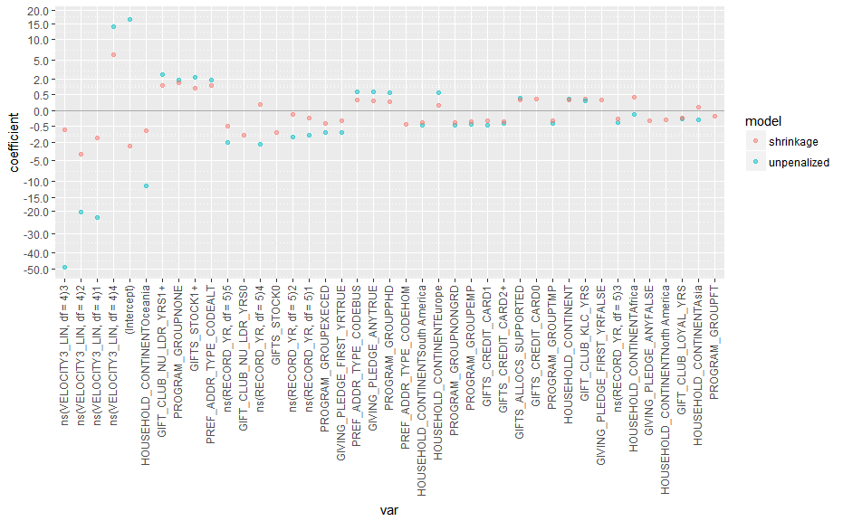

```r
neg_sqrt_trans <- function() scales::trans_new(
    'neg_sqrt'
  , function(x) {sign(x) * sqrt(abs(x))}
  , function(x) {sign(x) * x^2}
)
full_join(
    data.frame(var = coef(mnpen) %>% names(), unpenalized = coef(mnpen))
  , data.frame(var = coef(mpen)[, 1] %>% names(), shrinkage = coef(mpen)[, 1])
) %>% gather(model, 'coefficient', 2:3) %>%
  na.omit() %>%
  arrange(abs(coefficient) %>% desc()) %>%
  ggplot(aes(x = var %>% reorder(-abs(coefficient)), y = coefficient, color = model)) +
  geom_hline(yintercept = 0, color = 'darkgray') +
  geom_point(alpha = .5) +
  scale_y_continuous(trans = 'neg_sqrt', breaks = c(-50, -40, -30, seq(-20, 20, by = 5), -2, -.5, .5, 2)) +
  theme(axis.text.x = element_text(angle = 90, hjust = 1, vjust = .3)
            , panel.grid.minor = element_line(linetype = 'dotted')) +
  labs(x = 'var')
```

The penalization appears to be fairly strong. Note that the penalized model included dummy coding for the factor base levels (i.e. not folded into the intercept term).

Also note in the nonpenalized model the velocity coefficients are on the order of 10E1 which is extremely high compared to the average.

# Holdout data face-off

It’s now time for the moment we’ve all been waiting for! Error statistics will now be computed for each model on the heretofore unseen holdout data.

```r
# Training data proportion
theta <- sum(traindat$GAVE_10K) / nrow(traindat)
confus_test <- list(
    bad = conf_matrix(mbad, newdata = holdoutdat, threshold = theta)
  , baseline = conf_matrix(mbad, newdata = holdoutdat, threshold = theta)
  , trimmed = conf_matrix(mtrim3, newdata = holdoutdat, threshold = theta)
  , nonpenalized = conf_matrix(mnpen, newdata = holdoutdat, threshold = theta)
  , penalized = conf_matrix_glmnet(mpen, newdata = holdoutdat, threshold = theta)
)
```

## Results

```r
with(confus_test,
  list(
      bad = bad$conf_matrix
    , baseline = baseline$conf_matrix
    , trimmed = trimmed$conf_matrix
    , nonpenalized = nonpenalized$conf_matrix
    , penalized = penalized$conf_matrix
  )
)
```

```
$bad
     prediction
truth FALSE TRUE
    0  7934  594
    1     5   91

$baseline
     prediction
truth FALSE TRUE
    0  7934  594
    1     5   91

$trimmed
     prediction
truth FALSE TRUE
    0  7939  589
    1     7   89

$nonpenalized
     prediction
truth FALSE TRUE
    0  8041  487
    1     8   88

$penalized
     prediction
truth FALSE TRUE
    0  7758  770
    1     3   93
```

```r
with(confus_test,
  rbind(
      bad = data.frame(error = bad$error, precision = bad$precision, sensitivity = bad$sensitivity, F1 = bad$F1_score)
    , baseline = c(baseline$error, baseline$precision, baseline$sensitivity, baseline$F1_score)
    , trimmed = c(trimmed$error, trimmed$precision, trimmed$sensitivity, trimmed$F1_score)
    , nonpenalized = c(nonpenalized$error, nonpenalized$precision, nonpenalized$sensitivity, nonpenalized$F1_score)
    , penalized = c(penalized$error, penalized$precision, penalized$sensitivity, penalized$F1_score)
  )
) %>% round(4)
```

|  | error | precision | sensitivity | F1 |
| --- | --- | --- | --- | --- |
| bad | 0.0695 | 0.1328 | 0.9479 | 0.1165 |
| baseline | 0.0695 | 0.1328 | 0.9479 | 0.1165 |
| trimmed | 0.0691 | 0.1313 | 0.9271 | 0.1150 |
| nonpenalized | 0.0574 | 0.1530 | 0.9167 | 0.1311 |
| penalized | 0.0896 | 0.1078 | 0.9688 | 0.0970 |

Reassuringly, these results mirror those obtained during cross-validation.

The central question: prioritize low error or high sensitivity? This determines whether the nonpenalized or penalized model is “best.” Also recall that the nonpenalized model leans very heavily on `VELOCITY3_LIN` which is a point against.

## Calibration

The basic idea: regress classification on fitted predictions and see if there are poorly-calibrated areas, e.g. of the points with a predicted probability around 30% only 10% are donors.

### Internal calibration

A.k.a. in-sample results

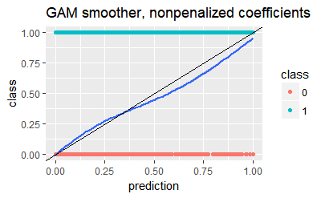

```r
# Nonpenalized data frame
data.frame(
    class = traindat$GAVE_10K
  , prediction = predict(mnpen, newdata = traindat, type = 'response')
) %>%
# Plot results
ggplot(aes(x = prediction, y = class)) +
  geom_point(aes(color = as.factor(class))) +
  geom_smooth(method = 'gam', formula = y ~ s(x, k = 5)) +
  geom_abline(slope = 1, intercept = 0) +
  labs(title = 'GAM smoother, nonpenalized coefficients', color = 'class')
```

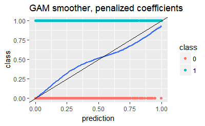

```r
# Penalized data frame
data.frame(
    class = traindat$GAVE_10K
  , prediction = predict(mpen, newdata = traindat, type = 'response')
) %>% mutate(prediction = X1) %>%
# Plot results
ggplot(aes(x = prediction, y = class)) +
  geom_point(aes(color = as.factor(class))) +
  geom_smooth(method = 'gam', formula = y ~ s(x, k = 5)) +
  geom_abline(slope = 1, intercept = 0) +
  labs(title = 'GAM smoother, penalized coefficients', color = 'class')
```

### External calibration

A.k.a. out-of-sample results

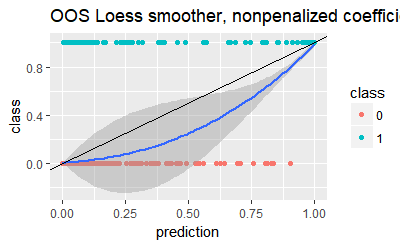

```r
# Nonpenalized data frame
data.frame(
    class = holdoutdat$GAVE_10K
  , prediction = predict(mnpen, newdata = holdoutdat, type = 'response')
) %>%
# Plot results
ggplot(aes(x = prediction, y = class)) +
  geom_point(aes(color = as.factor(class))) +
  geom_smooth(method = 'loess') +
  geom_abline(slope = 1, intercept = 0) +
  labs(title = 'OOS Loess smoother, nonpenalized coefficients', color = 'class')
```

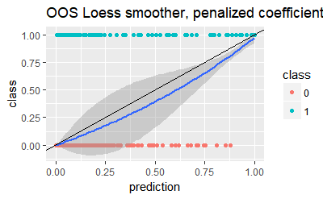

```r
# Penalized data frame
data.frame(
    class = holdoutdat$GAVE_10K
  , prediction = predict(mpen, newdata = holdoutdat, type = 'response')
) %>% mutate(prediction = X1) %>%
# Plot results
ggplot(aes(x = prediction, y = class)) +
  geom_point(aes(color = as.factor(class))) +
  geom_smooth(method = 'loess') +
  geom_abline(slope = 1, intercept = 0) +
  labs(title = 'OOS Loess smoother, penalized coefficients', color = 'class')
```